# Lines(ggplot2

Jeswin

1 October 2017

Blog

# Lines(ggplot2)

```r
# loading libraries
library(ggplot2)
library(gridExtra)
suppressMessages(library(dplyr))
```

## With one continuous and one categorical axis

```r
# Some sample data
dat <- read.table(header = TRUE, text = '
                  cond  result
                  Control 10
                  treatment 11.5
                  ')
dat
```

```
##        cond result
## 1   Control   10.0
## 2 treatment   11.5
```

## Lines that go all the way across

These use **geom_hline** because the y-axis is the continuous one, but it is also possible to use geom_vline (with xintercept) if the x-axis is continuous

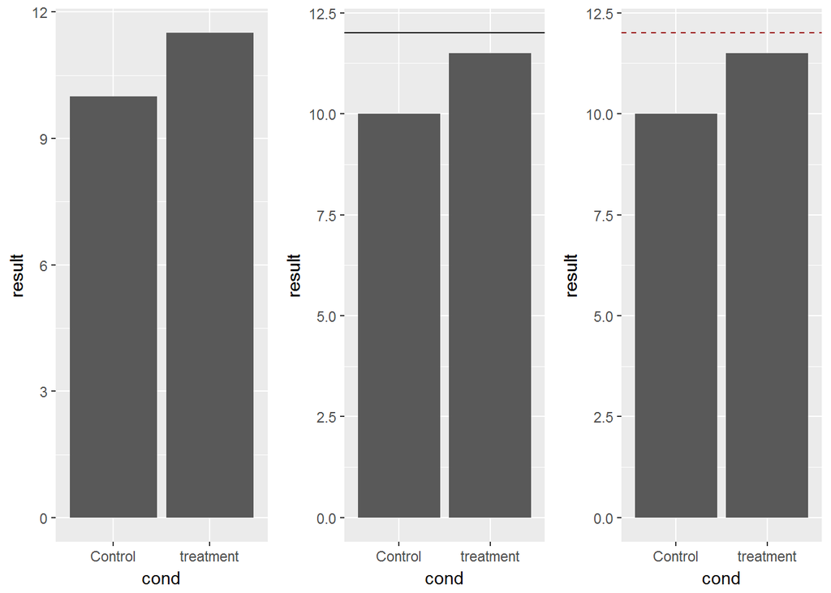

```r
# Basic bar graph
bp <- ggplot(dat, aes(x=cond, y=result)) +
    geom_bar(position=position_dodge(), stat="identity")

# Add a horizontal line
bp2 <- bp + geom_hline(aes(yintercept = 12))

# Make the line red and dashed
bp3 <- bp + geom_hline(aes(yintercept = 12), color = '#990000', linetype = 'dashed')

grid.arrange(bp,bp2,bp3, ncol=3)
```

## Separate lines for each categorical value

To make separate lines for each bar, use **geom_errorbar**. The error bars have no height - ‘ymin=ymax’ . It also seems necessary to specify y for some reason, even though it doesn’t do anything.

```r
dat$hline <- c(9,12)
dat
```

```
##        cond result hline
## 1   Control   10.0     9
## 2 treatment   11.5    12
```